# PA1 REproducible Research

Guillermo Jasso

Wednesday, January 14, 2015

This document presents the results of the Reproducible Research’s Peer Assessment 1 in a report using a single R markdown document that can be processed by knitr and be transformed into an HTML file

# We will start firts by Loading and preprocessing the data

```r
activity <- read.csv("activity.csv",colClasses = c("numeric", "character", "numeric"))
head(activity)
```

```
##   steps      date interval
## 1    NA 10/1/2012        0
## 2    NA 10/1/2012        5
## 3    NA 10/1/2012       10
## 4    NA 10/1/2012       15
## 5    NA 10/1/2012       20
## 6    NA 10/1/2012       25
```

```r
names(activity)
```

```
## [1] "steps"    "date"     "interval"
```

```r
str(activity)
```

```
## 'data.frame':    17568 obs. of  3 variables:
##  $ steps   : num  NA NA NA NA NA NA NA NA NA NA ...
##  $ date    : chr  "10/1/2012" "10/1/2012" "10/1/2012" "10/1/2012" ...
##  $ interval: num  0 5 10 15 20 25 30 35 40 45 ...
```

# Now we start answering the questions

## What is the mean total number of stepts taken per day?

### First we aggregate the data

```r
StepsTotal <- aggregate(steps ~ date, activity, sum)
```

### Then we plot the data on an Histogram

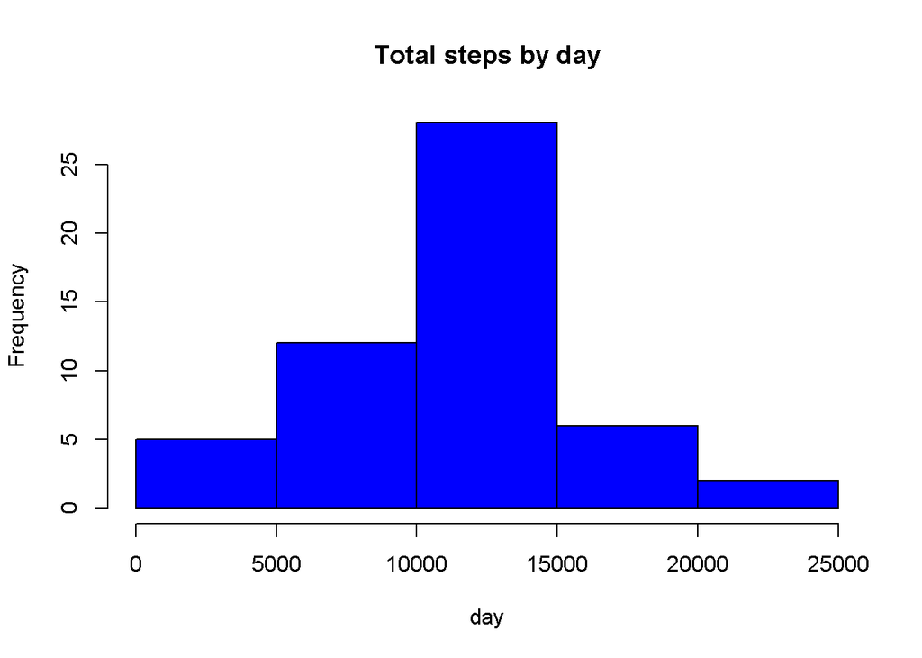

```r
hist(StepsTotal$steps, main = "Total steps by day", xlab = "day", col = "blue")
```

```r
dev.copy(png, file="hist1.png", height=480, width=480)
```

```r
dev.off()
```

## And the Mean and the Median are

```r
mean(StepsTotal$steps)
```

```
## [1] 10766.19
```

```r
median(StepsTotal$steps)
```

```
## [1] 10765
```

## What is the average daily activity pattern?

### Getting the mean of steps and time series plot

```r
time_series <- tapply(activity$steps, activity$interval, mean, na.rm = TRUE)
```

### And then we plot the data

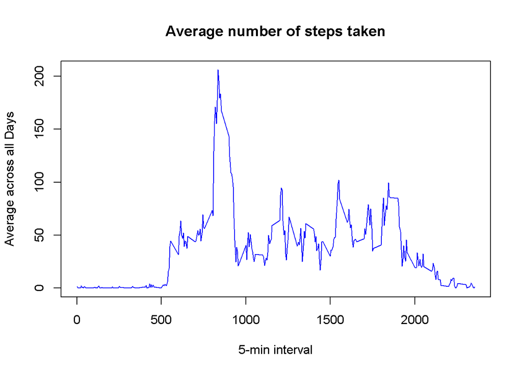

```r
plot(row.names(time_series), time_series, type = "l", xlab = "5-min interval",
     ylab = "Average across all Days", main = "Average number of steps taken",
     col = "blue")
```

```r
dev.copy(png, file="hist2.png", height=480, width=480)
```

```r
dev.off()
```

### Which 5-minute interval, on average across all the days in the dataset, contains the maximum number of steps?

```r
max_interval <- which.max(time_series)
names(max_interval)
```

```
## [1] "835"
```

## Imputing missing values

### Calculate and report the total number of missing values in the dataset

```r
activity_NA <- sum(is.na(activity))
activity_NA
```

```
## [1] 2304
```

### Devise a strategy for filling in all of the missing values in the dataset

### We will replaced NA by the mean in 5 min interval

```r
StepsAverage <- aggregate(steps ~ interval, data = activity, FUN = mean)
fillNA <- numeric()
for (i in 1:nrow(activity)) {
    obs <- activity[i, ]
    if (is.na(obs$steps)) {
        steps <- subset(StepsAverage, interval == obs$interval)$steps
    } else {
        steps <- obs$steps
    }
    fillNA <- c(fillNA, steps)
}
```

### Then we create a new dataset that is equal to the original dataset but with the missing data filled in

```r
new_activity <- activity
new_activity$steps <- fillNA
```

### Make a histogram of the total number of steps taken each day and Calculate and report the mean and median total number of steps taken per day

```r
StepsTotal2 <- aggregate(steps ~ date, new_activity, sum)
```

### We plot the data

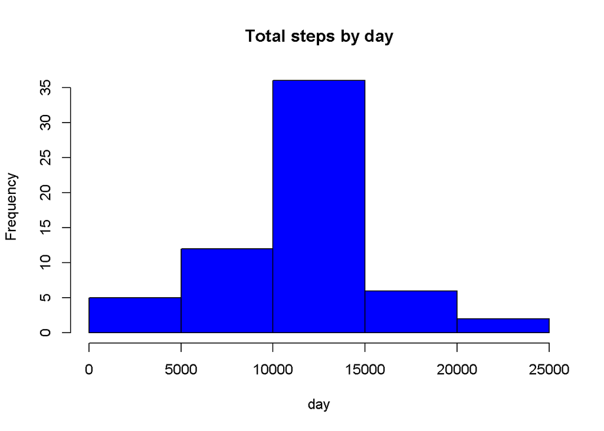

```r
hist(StepsTotal2$steps, main = "Total steps by day", xlab = "day", col = "blue")
```

```r
dev.copy(png, file="hist3.png", height=480, width=480)
```

```r
dev.off()
```

### Mean and Median

```r
mean(StepsTotal2$steps)
```

```
## [1] 10766.19
```

```r
median(StepsTotal2$steps)
```

```
## [1] 10766.19
```

## We found the values are just slightly different

# Are there differences in activity patterns between weekdays and weekends?

### Create a new factor variable in the dataset with two levels  “weekday” and “weekend” indicating whether a given date is a weekday or weekend day

```r
activity <- read.csv("activity.csv",colClasses = c("numeric", "Date", "numeric"))
daytype <- function(date) {
    if (weekdays(as.Date(date)) %in% c("Saturday", "Sunday")) {
        "weekend"
    } else {
        "weekday"
    }
}
activity$daytype <- as.factor(sapply(activity$date, daytype))
```

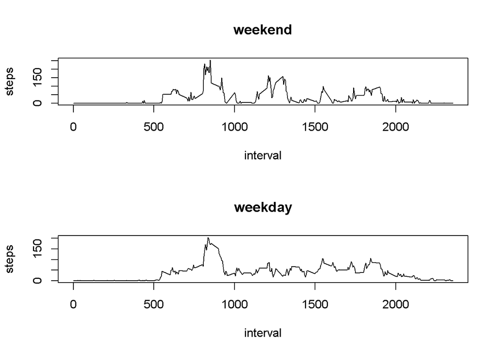

```r
par(mfrow = c(2, 1))
for (type in c("weekend", "weekday")) {
    steps.type <- aggregate(steps ~ interval, data = activity, subset = activity$daytype ==
        type, FUN = mean)
    plot(steps.type, type = "l", main = type)
}
```

```r
dev.copy(png, file="hist4.png", height=480, width=480)
```

```r
dev.off()
```

# Hope is clear enough to Reproduce! thanks!!